# Practical Machine Learning Course Project

Eiryie  
July 2015

## Project Purpose

The goal of this project is to develop a model in R able to accurately predict the manner in which test subjects performed a weight-lifting exercise.

## Project Data

The training and test sets were provided by the course administrators. The data is the result of six young health participants who were asked to perform one set of 10 repetitions of the Unilateral Dumbbell Biceps Curl in five different fashions: exactly according to the specification (Class A), throwing the elbows to the front (Class B), lifting the dumbbell only halfway (Class C), lowering the dumbbell only halfway (Class D) and throwing the hips to the front (Class E). A full description is available at: http://groupware.les.inf.puc-rio.br/har#ixzz3gdYKUKYc.

A cursory review of the training and test sets show that there are several fields with null values. Therefore, these should be addressed when loading the data.

```r
## Load the required packages
library(caret)
```

```r
library(rpart)
library(rpart.plot)
library(randomForest)
library(doParallel)
registerDoParallel(cores=2)

## Load datasets
test<-read.csv("~/RDirect/pml-testing.csv", na.strings=c("NA","#DIV/0!", ""),header=TRUE)
train<-read.csv("~/RDirect/pml-training.csv", na.strings=c("NA","#DIV/0!", ""),header=TRUE)
```

## Data Cleaning

A preliminary review of the training and test sets show that there are 19622 observations of 160 variables in the training set and 20 observations of 160 variables in the test set. It is important to note that column 160 in the sets are different. The training set includes the exercise fashion (classe). The test set includes a column for the project id.

Columns reflecting only descriptive data on the observation (e.g., subject name) will not be useful for this model. Therefore, they can be removed.

```r
trainc<-train[-c(1:7)]
testc<-test[-c(1:7)]
```

Several columns consist primarily of null values. The lack of data in these columns means that they will not be useful as predictors. Therefore, they can also be dropped. This leaves us with 53 columns in each set.

```r
## Identify columns that have at least 50% null values
na_count <- sapply(trainc, function(y) sum(length(which(is.na(y)))))
na_count <- data.frame(na_count)
na_count2 <- data.frame(column=row.names(na_count), na_count)
exclude <- na_count2[which(na_count2[,2]>=9811),]

## Remove columns with at least 50% null values from the training and test sets
trainc <- trainc[,!(names(trainc) %in% exclude$column)]
testc <- testc[,!(names(testc) %in% exclude$column)]
```

A near-zero variance analysis confirms that the remaining columns should have some value for the predictive model.

```r
nsv <- nearZeroVar(trainc, saveMetrics=TRUE)
nsv
```

```
##                      freqRatio percentUnique zeroVar   nzv
## roll_belt             1.101904     6.7781062   FALSE FALSE
## pitch_belt            1.036082     9.3772296   FALSE FALSE
## yaw_belt              1.058480     9.9734991   FALSE FALSE
## total_accel_belt      1.063160     0.1477933   FALSE FALSE
## gyros_belt_x          1.058651     0.7134849   FALSE FALSE
## gyros_belt_y          1.144000     0.3516461   FALSE FALSE
## gyros_belt_z          1.066214     0.8612782   FALSE FALSE
## accel_belt_x          1.055412     0.8357966   FALSE FALSE
## accel_belt_y          1.113725     0.7287738   FALSE FALSE
## accel_belt_z          1.078767     1.5237998   FALSE FALSE
## magnet_belt_x         1.090141     1.6664968   FALSE FALSE
## magnet_belt_y         1.099688     1.5187035   FALSE FALSE
## magnet_belt_z         1.006369     2.3290184   FALSE FALSE
## roll_arm             52.338462    13.5256345   FALSE FALSE
## pitch_arm            87.256410    15.7323412   FALSE FALSE
## yaw_arm              33.029126    14.6570176   FALSE FALSE
## total_accel_arm       1.024526     0.3363572   FALSE FALSE
## gyros_arm_x           1.015504     3.2769341   FALSE FALSE
## gyros_arm_y           1.454369     1.9162165   FALSE FALSE
## gyros_arm_z           1.110687     1.2638875   FALSE FALSE
## accel_arm_x           1.017341     3.9598410   FALSE FALSE
## accel_arm_y           1.140187     2.7367241   FALSE FALSE
## accel_arm_z           1.128000     4.0362858   FALSE FALSE
## magnet_arm_x          1.000000     6.8239731   FALSE FALSE
## magnet_arm_y          1.056818     4.4439914   FALSE FALSE
## magnet_arm_z          1.036364     6.4468454   FALSE FALSE
## roll_dumbbell         1.022388    84.2065029   FALSE FALSE
## pitch_dumbbell        2.277372    81.7449801   FALSE FALSE
## yaw_dumbbell          1.132231    83.4828254   FALSE FALSE
## total_accel_dumbbell  1.072634     0.2191418   FALSE FALSE
## gyros_dumbbell_x      1.003268     1.2282132   FALSE FALSE
## gyros_dumbbell_y      1.264957     1.4167771   FALSE FALSE
## gyros_dumbbell_z      1.060100     1.0498420   FALSE FALSE
## accel_dumbbell_x      1.018018     2.1659362   FALSE FALSE
## accel_dumbbell_y      1.053061     2.3748853   FALSE FALSE
## accel_dumbbell_z      1.133333     2.0894914   FALSE FALSE
## magnet_dumbbell_x     1.098266     5.7486495   FALSE FALSE
## magnet_dumbbell_y     1.197740     4.3012945   FALSE FALSE
## magnet_dumbbell_z     1.020833     3.4451126   FALSE FALSE
## roll_forearm         11.589286    11.0895933   FALSE FALSE
## pitch_forearm        65.983051    14.8557741   FALSE FALSE
## yaw_forearm          15.322835    10.1467740   FALSE FALSE
## total_accel_forearm   1.128928     0.3567424   FALSE FALSE
## gyros_forearm_x       1.059273     1.5187035   FALSE FALSE
## gyros_forearm_y       1.036554     3.7763735   FALSE FALSE
## gyros_forearm_z       1.122917     1.5645704   FALSE FALSE
## accel_forearm_x       1.126437     4.0464784   FALSE FALSE
## accel_forearm_y       1.059406     5.1116094   FALSE FALSE
## accel_forearm_z       1.006250     2.9558659   FALSE FALSE
## magnet_forearm_x      1.012346     7.7667924   FALSE FALSE
## magnet_forearm_y      1.246914     9.5403119   FALSE FALSE
## magnet_forearm_z      1.000000     8.5771073   FALSE FALSE
## classe                1.469581     0.0254816   FALSE FALSE
```

## Model Design

### Create a Partition

In order to allow cross-validation, split the training set to have 60% of the original clean training data to be used for training the model and the other 40% to be used as the new testing set.

```r
set.seed(2000)
intrain <- createDataPartition(trainc$classe, p=0.60, list=FALSE)
subTrainc <- trainc[intrain, ]
subTestc <- trainc[-intrain, ]
```

### Basic Classification Tree

We start with a basic prediction tree. However, we find this model only correctly predicts the classe variable about 50% of the time.

```r
## Run model
modFit<-train(classe~.,method="rpart", data=subTrainc)
modFit
```

```
## CART
##
## 11776 samples
##    52 predictor
##     5 classes: 'A', 'B', 'C', 'D', 'E'
##
## No pre-processing
## Resampling: Bootstrapped (25 reps)
## Summary of sample sizes: 11776, 11776, 11776, 11776, 11776, 11776, ...
## Resampling results across tuning parameters:
##
##   cp          Accuracy   Kappa       Accuracy SD  Kappa SD
##   0.03630755  0.5041905  0.35391643  0.01639229   0.02498908
##   0.06059168  0.4167145  0.21089903  0.06439064   0.10614404
##   0.11449929  0.3227783  0.05905263  0.04196332   0.06278589
##
## Accuracy was used to select the optimal model using  the largest value.
## The final value used for the model was cp = 0.03630755.
```

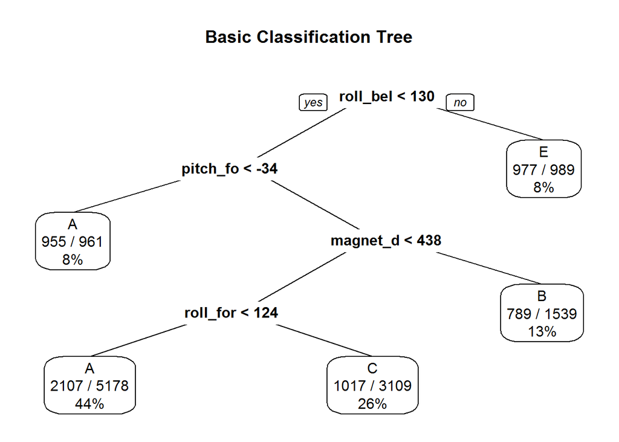

```r
## Plot the final model
rpart.plot(modFit$finalModel, main="Basic Classification Tree", extra=102)
```

```r
## Evaluate how well the model works on the partitioned training test set
test1 <- predict(modFit, subTestc)
confusionMatrix(test1, subTestc$classe)
```

```
## Confusion Matrix and Statistics
##
##           Reference
## Prediction    A    B    C    D    E
##          A 2013  650  632  584  203
##          B   44  507   32  231  213
##          C  173  361  704  471  372
##          D    0    0    0    0    0
##          E    2    0    0    0  654
##
## Overall Statistics
##
##                Accuracy : 0.4943
##                  95% CI : (0.4831, 0.5054)
##     No Information Rate : 0.2845
##     P-Value [Acc > NIR] : < 2.2e-16
##
##                   Kappa : 0.339
##  Mcnemar's Test P-Value : NA
##
## Statistics by Class:
##
##                      Class: A Class: B Class: C Class: D Class: E
## Sensitivity            0.9019  0.33399  0.51462   0.0000  0.45354
## Specificity            0.6315  0.91783  0.78743   1.0000  0.99969
## Pos Pred Value         0.4931  0.49367  0.33830      NaN  0.99695
## Neg Pred Value         0.9418  0.85174  0.88482   0.8361  0.89040
## Prevalence             0.2845  0.19347  0.17436   0.1639  0.18379
## Detection Rate         0.2566  0.06462  0.08973   0.0000  0.08335
## Detection Prevalence   0.5203  0.13089  0.26523   0.0000  0.08361
## Balanced Accuracy      0.7667  0.62591  0.65103   0.5000  0.72661
```

### Random Forest

In order to achieve a higher predictive success rate, we next try a random forest approach. Although this model takes over 12 hours to train even using parallel processing on a quad core/8GB RAM computer, the results are worth the wait. The random forest approach creates a model with an accuracy rate of over 99%.

```r
## Run model
modRF<-train(classe~.,method="rf", data=subTrainc, prox=TRUE)
modRF
```

```
## Random Forest
##
## 11776 samples
##    52 predictor
##     5 classes: 'A', 'B', 'C', 'D', 'E'
##
## No pre-processing
## Resampling: Bootstrapped (25 reps)
## Summary of sample sizes: 11776, 11776, 11776, 11776, 11776, 11776, ...
## Resampling results across tuning parameters:
##
##   mtry  Accuracy   Kappa      Accuracy SD  Kappa SD
##    2    0.9859926  0.9822723  0.003087880  0.003908811
##   27    0.9868197  0.9833215  0.002246959  0.002837978
##   52    0.9754543  0.9689410  0.005012009  0.006322989
##
## Accuracy was used to select the optimal model using  the largest value.
## The final value used for the model was mtry = 27.
```

```r
## Evaluate how well the model works on the partitioned training test set
test2 <- predict(modRF, subTestc)
confusionMatrix(test2, subTestc$classe)
```

```
## Confusion Matrix and Statistics
##
##           Reference
## Prediction    A    B    C    D    E
##          A 2228    9    0    0    0
##          B    3 1504    7    1    0
##          C    0    4 1351   18    1
##          D    0    1   10 1267    5
##          E    1    0    0    0 1436
##
## Overall Statistics
##
##                Accuracy : 0.9924
##                  95% CI : (0.9902, 0.9942)
##     No Information Rate : 0.2845
##     P-Value [Acc > NIR] : < 2.2e-16
##
##                   Kappa : 0.9903
##  Mcnemar's Test P-Value : NA
##
## Statistics by Class:
##
##                      Class: A Class: B Class: C Class: D Class: E
## Sensitivity            0.9982   0.9908   0.9876   0.9852   0.9958
## Specificity            0.9984   0.9983   0.9964   0.9976   0.9998
## Pos Pred Value         0.9960   0.9927   0.9833   0.9875   0.9993
## Neg Pred Value         0.9993   0.9978   0.9974   0.9971   0.9991
## Prevalence             0.2845   0.1935   0.1744   0.1639   0.1838
## Detection Rate         0.2840   0.1917   0.1722   0.1615   0.1830
## Detection Prevalence   0.2851   0.1931   0.1751   0.1635   0.1832
## Balanced Accuracy      0.9983   0.9945   0.9920   0.9914   0.9978
```

## Test Set Prediction

In order to complete the assignment, we apply the random forest model to the Test set originally provided by the course administrators. As shown in the confusion matrix cross-validation, the expected out-of-sample error for this prediction is 0.0076 (1-0.9924). Therefore, we expect less than 1% of the predicted values to be erroneous.

```r
answers <- predict(modRF, test)
answers
```

```
##  [1] B A B A A E D B A A B C B A E E A B B B
## Levels: A B C D E
```